# Food at College

```r
# From your file menu (at the top of R-Studio) select:
# "Session -> Set working directory -> To source file location"
# Then play this chunk to get the data into R.
library(mosaic)
library(car)
library(DT)
library(pander)
library(readr)
food <- read_csv("food.csv")
```

## Background

This analysis uses the “Food Choices” dataset from Kaggle (© 2020 Kaggle Inc), which surveys college students about their eating habits, lifestyle choices, and demographic information. The dataset includes 125 students and contains various nutritional, dietary, and lifestyle variables.

After exploring the dataset, I became interested in whether students’ exercise habits are associated with measurable health and academic outcomes. Exercise is often promoted as beneficial for both physical health and cognitive performance, but does this hold true in our college student population? This led me to examine two questions:

1. **Does exercise frequency relate to GPA?** Regular physical activity is said to improve focus, memory, and academic performance.
2. **Does exercise frequency relate to body weight?** Exercise is commonly associated with weight management and overall physical health.

To answer these questions, I will use the Kruskal-Wallis test, which is appropriate for comparing a quantitative variable (GPA or weight) across multiple groups (exercise frequencies) when we cannot assume the data are normally distributed.

## Analysis 1: Exercise Frequency and GPA

### Research Question

Is there a difference in median GPA among college students based on their exercise frequency?

### Hypotheses

**Null Hypothesis ($H_0$):** The median GPA is the same across all exercise frequency groups.

**Alternative Hypothesis ($H_a$):** At least one exercise frequency group has a different median GPA than the others.

**Significance Level:** $\alpha = 0.05$

### Analysis

```r
# Define labels for exercise frequency (excluding "Sometimes" and "Never")
exercise_labels <- c("1" = "Everyday",
                     "2" = "2-3x a week",
                     "3" = "Once a week")

# Clean data: remove missing values and filter for exercise groups 1-3
food$GPA <- as.numeric(food$GPA)
# Filter to keep only exercise levels 1, 2, and 3
food_subset <- subset(food, exercise %in% c(1, 2, 3))
gpa_exercise_clean <- na.omit(food_subset[, c("GPA", "exercise")])

# Create factor variable with meaningful labels
gpa_exercise_clean$exercise_factor <- factor(gpa_exercise_clean$exercise,
                                              levels = 1:3,
                                              labels = exercise_labels)

# Descriptive statistics
desc_stats_gpa <- favstats(GPA ~ exercise_factor, data = gpa_exercise_clean)

pander(desc_stats_gpa,
       caption = "Descriptive Statistics: GPA by Exercise Frequency")
```

Descriptive Statistics: GPA by Exercise Frequency

| exercise_factor | min | Q1 | median | Q3 | max | mean | sd | n | missing |
| --- | --- | --- | --- | --- | --- | --- | --- | --- | --- |
| Everyday | 2.4 | 3.2 | 3.5 | 3.725 | 4 | 3.434 | 0.3795 | 55 | 0 |
| 2-3x a week | 2.2 | 3.1 | 3.5 | 3.765 | 4 | 3.419 | 0.4466 | 43 | 0 |
| Once a week | 2.6 | 3.2 | 3.4 | 3.4 | 3.7 | 3.255 | 0.3078 | 11 | 0 |

### Graphical Summary

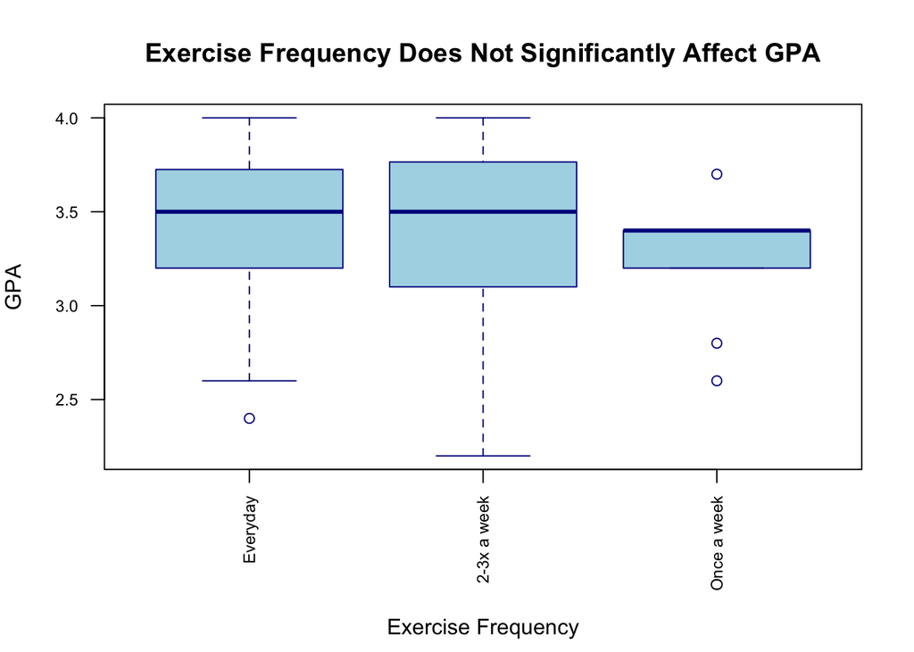

```r
# Set larger bottom margin for rotated labels
par(mar = c(7, 4, 4, 2))

boxplot(GPA ~ exercise_factor,
        data = gpa_exercise_clean,
        main = "Exercise Frequency Does Not Significantly Affect GPA",
        xlab = "",
        ylab = "GPA",
        col = "lightblue",
        border = "darkblue",
        las = 2,
        cex.axis = 0.75)

# Add x-axis label with more space
mtext("Exercise Frequency", side = 1, line = 5.5)
```

```r
# Reset to default margins
par(mar = c(5, 4, 4, 2))
```

### Test Results

```r
# Perform Kruskal-Wallis test
kw_test_gpa <- kruskal.test(GPA ~ exercise_factor, data = gpa_exercise_clean)

# Pander the results
pander(kw_test_gpa)
```

Kruskal-Wallis rank sum test: `GPA` by `exercise_factor`

| Test statistic | df | P value |
| --- | --- | --- |
| 2.872 | 2 | 0.2379 |

### Interpretation

The Kruskal-Wallis test yielded a chi-squared statistic of 2.872 with 2 degrees of freedom and a p-value of 0.2379.

Since the p-value (0.2379) is greater than our significance level of $\alpha = 0.05$, **we fail to reject the null hypothesis**.

**Conclusion:** There is no statistically significant evidence to suggest that median GPA differs based on exercise frequency among college students in this sample. The overall median GPA for these students is 3.5, and no group differed significantly from this value. The “Sometimes” and “Never” exercise groups were excluded from this analysis to focus on students with more defined exercise habits.

## Analysis 2: Exercise Frequency and Weight

### Research Question

Is there a difference in median body weight among college students based on their exercise frequency?

### Hypotheses

**Null Hypothesis ($H_0$):** The median weight is the same across all exercise frequency groups.

**Alternative Hypothesis ($H_a$):** At least one exercise frequency group has a different median weight than the others.

**Significance Level:** $\alpha = 0.05$

### Analysis

```r
# Clean data: remove missing values and filter for exercise groups 1-3
food$weight <- as.numeric(food$weight)
# Filter to keep only exercise levels 1, 2, and 3
food_subset_weight <- subset(food, exercise %in% c(1, 2, 3))
weight_exercise_clean <- na.omit(food_subset_weight[, c("weight", "exercise")])

# Create factor variable with meaningful labels
weight_exercise_clean$exercise_factor <- factor(weight_exercise_clean$exercise,
                                                 levels = 1:3,
                                                 labels = exercise_labels)

# Descriptive statistics
desc_stats_weight <- favstats(weight ~ exercise_factor, data = weight_exercise_clean)

pander(desc_stats_weight,
       caption = "Descriptive Statistics: Weight (lbs) by Exercise Frequency")
```

Descriptive Statistics: Weight (lbs) by Exercise Frequency

| exercise_factor | min | Q1 | median | Q3 | max | mean | sd | n | missing |
| --- | --- | --- | --- | --- | --- | --- | --- | --- | --- |
| Everyday | 110 | 140 | 160 | 180 | 260 | 160.7 | 27.91 | 57 | 0 |
| 2-3x a week | 112 | 130 | 150 | 170 | 210 | 153.9 | 26.76 | 41 | 0 |
| Once a week | 128 | 145 | 167.5 | 188.8 | 264 | 173.7 | 39.77 | 10 | 0 |

### Graphical Summary

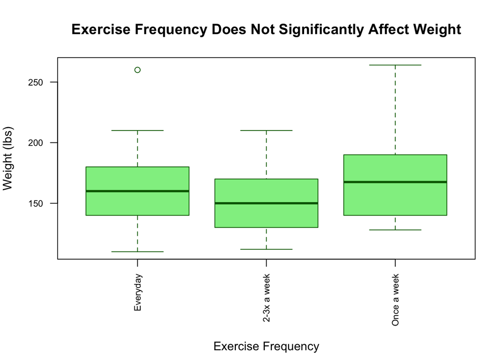

```r
# Set larger bottom margin for rotated labels
par(mar = c(7, 4, 4, 2))

boxplot(weight ~ exercise_factor,
        data = weight_exercise_clean,
        main = "Exercise Frequency Does Not Significantly Affect Weight",
        xlab = "",
        ylab = "Weight (lbs)",
        col = "lightgreen",
        border = "darkgreen",
        las = 2,
        cex.axis = 0.75)

# Add x-axis label with more space
mtext("Exercise Frequency", side = 1, line = 5.5)
```

```r
# Reset to default margins
par(mar = c(5, 4, 4, 2))
```

### Test Results

```r
# Perform Kruskal-Wallis test
kw_test_weight <- kruskal.test(weight ~ exercise_factor, data = weight_exercise_clean)

# Pander the results
pander(kw_test_weight)
```

Kruskal-Wallis rank sum test: `weight` by `exercise_factor`

| Test statistic | df | P value |
| --- | --- | --- |
| 2.695 | 2 | 0.2599 |

### Interpretation

The Kruskal-Wallis test produced a chi-squared statistic of 2.695 with 2 degrees of freedom and a p-value of 0.2599.

Since the p-value (0.2599) is greater than our significance level of $\alpha = 0.05$, **we fail to reject the null hypothesis**.

**Conclusion:** There is no statistically significant evidence to suggest that median weight differs based on exercise frequency among college students in this sample. The overall median weight for these students is 155.5 lbs, and no group differed significantly from this value..